# AMAP: Assisted Microbial Annotation Pipeline Report

## Compared to Reference

*This section compares query genomes against the median distribution across all samples. Deviations indicate genome-specific gains or losses in functional categories.*

### Overview

[interactive chart not shown]

### Per Category

#### cell wall and cell processes

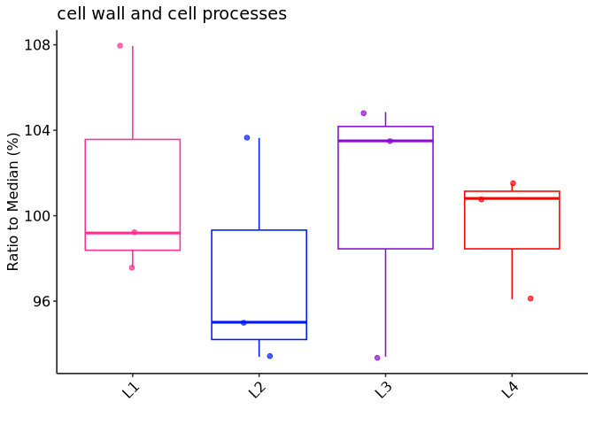

#### conserved hypotheticals

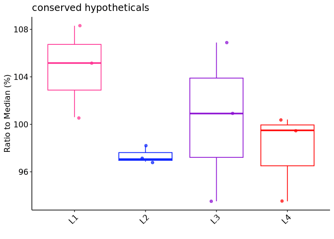

#### information pathways

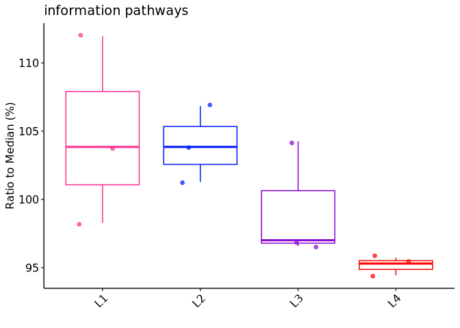

#### insertion seqs and phages

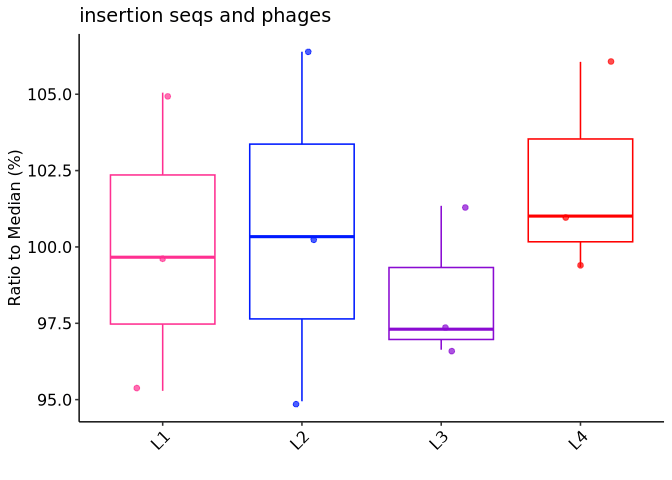

#### intermediary metabolism and respiration

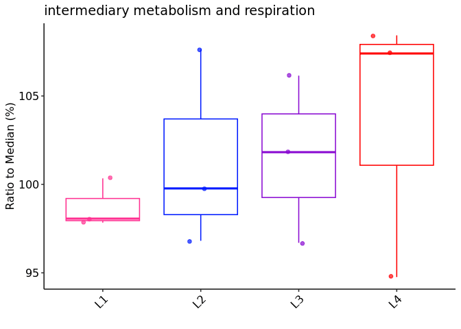

#### lipid metabolism

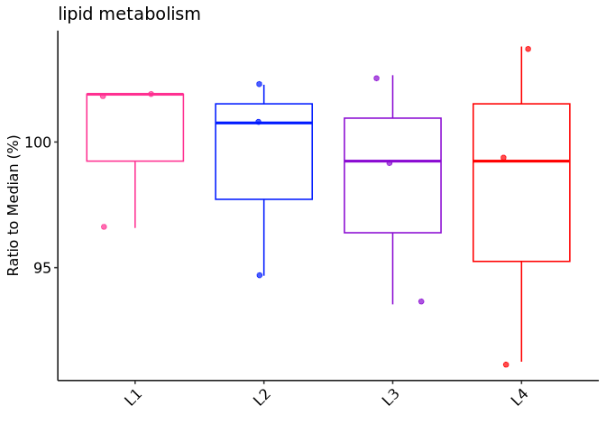

#### PE/PPE

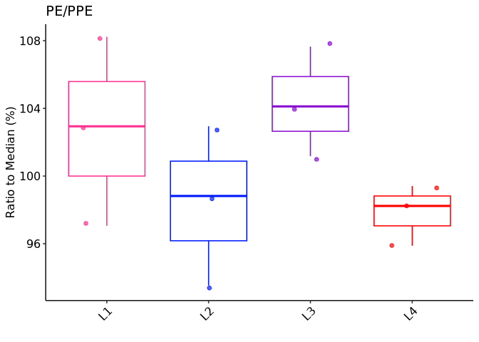

#### regulatory proteins

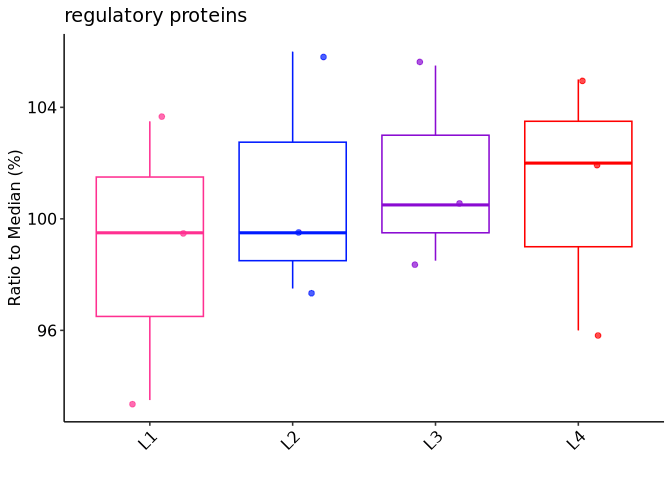

#### virulence, detoxification, adaptation

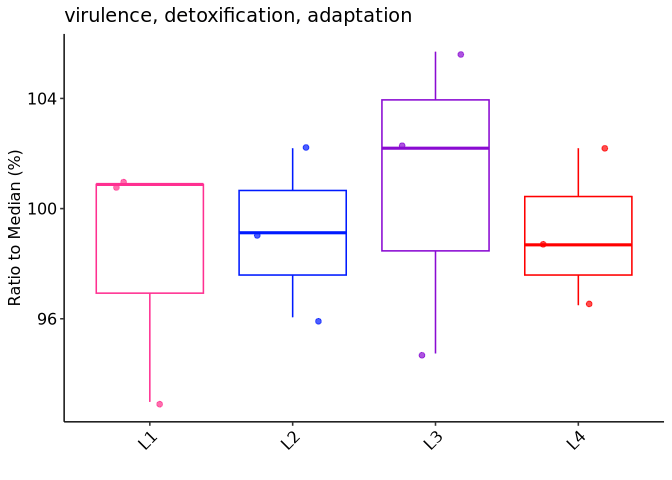

### Statistics

| Lineages | Functional_Category | Count | Mean_Ratio | SD_Ratio |
| --- | --- | --- | --- | --- |
| L1 | PE/PPE | 3 | 102.75 | 5.59 |
| L1 | cell wall and cell processes | 3 | 101.57 | 5.58 |
| L1 | conserved hypotheticals | 3 | 104.69 | 3.87 |
| L1 | information pathways | 3 | 104.7 | 6.88 |
| L1 | insertion seqs and phages | 3 | 100 | 4.89 |
| L1 | intermediary metabolism and respiration | 3 | 98.75 | 1.39 |
| L1 | lipid metabolism | 3 | 100.13 | 3.07 |
| L1 | regulatory proteins | 3 | 98.83 | 5.03 |
| L1 | virulence, detoxification, adaptation | 3 | 98.25 | 4.56 |
| L2 | PE/PPE | 3 | 98.43 | 4.72 |

[output cut: 26 more lines]

## PE/PPE Gene Families

*PE/PPE genes are characteristic of Mycobacteria. This section is only shown when Mycobrowser functional categories are available.*

### Distribution per Lineage

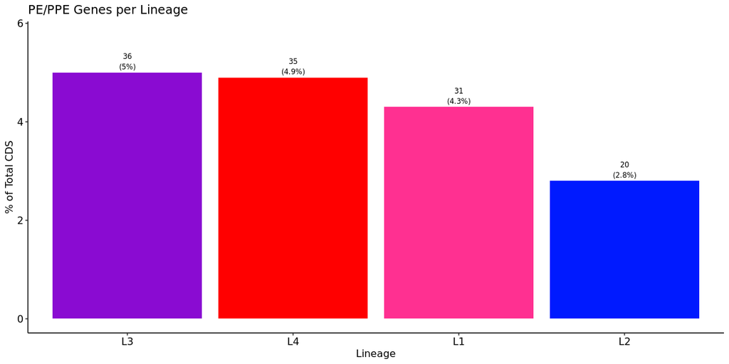

### Statistics

| lineage | total | peppe | pct |
| --- | --- | --- | --- |
| L1 | 720 | 31 | 4.3 |
| L2 | 720 | 20 | 2.8 |
| L3 | 720 | 36 | 5 |
| L4 | 720 | 35 | 4.9 |

## KEGG Pathway Analysis

Distribution of KEGG pathway annotations across lineages.

### Top Pathways

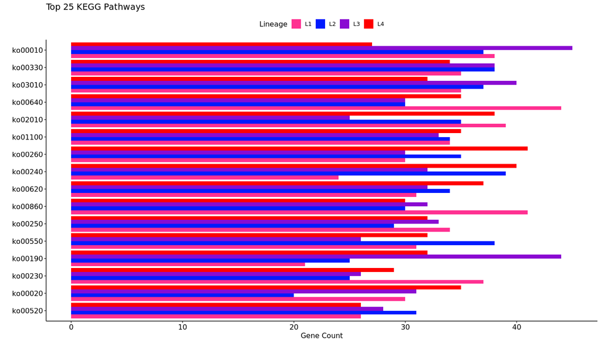

### Full Table

| KEGG_Pathway | L1 | L2 | L3 | L4 | Total |
| --- | --- | --- | --- | --- | --- |
| ko00010 | 38 | 37 | 45 | 27 | 147 |
| ko00330 | 35 | 38 | 38 | 34 | 145 |
| ko03010 | 35 | 37 | 40 | 32 | 144 |
| ko00640 | 44 | 30 | 30 | 35 | 139 |
| ko02010 | 39 | 35 | 25 | 38 | 137 |
| ko00260 | 30 | 35 | 30 | 41 | 136 |
| ko01100 | 34 | 34 | 33 | 35 | 136 |
| ko00240 | 24 | 39 | 32 | 40 | 135 |
| ko00620 | 31 | 34 | 32 | 37 | 134 |
| ko00860 | 41 | 30 | 32 | 30 | 133 |

[output cut: 6 more lines]

## Pseudogene Detection

The genes AMAP calls pseudogenes in each sample, by lineage: internal stop codons, a frameshift or lost stop that makes the frame run on past the end of the reference protein, no stop codon within reach, or a stop the reference itself lacks. They are the genes the GFF3 marks `pseudo=true` and the QC table counts, and the master table’s `note` column says why each one is a pseudogene. A sample with none counts 0. Mycobrowser’s `Is_Pseudogene` says whether a gene is a pseudogene in H37Rv, not in the sample, and is not counted.

### By Lineage

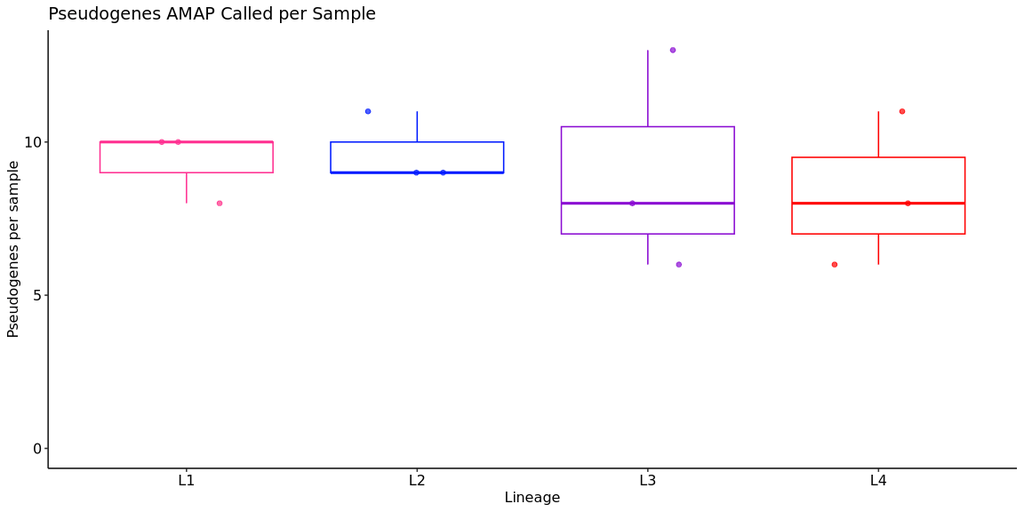

### Per Sample

| Lineage | Sample | Pseudogenes |
| --- | --- | --- |
| L1 | L1_G10000 | 8 |
| L1 | L1_G10007 | 10 |
| L1 | L1_G10014 | 10 |
| L2 | L2_G10100 | 11 |
| L2 | L2_G10107 | 9 |
| L2 | L2_G10114 | 9 |
| L3 | L3_G10200 | 8 |
| L3 | L3_G10207 | 13 |
| L3 | L3_G10214 | 6 |
| L4 | L4_G10300 | 6 |

[output cut: 2 more lines]

# Gene Duplications

Gene duplications detected by all-vs-all Diamond BLASTp within and across genomes.

## Duplication Summary

**48** homologous community pairs detected across all genomes.

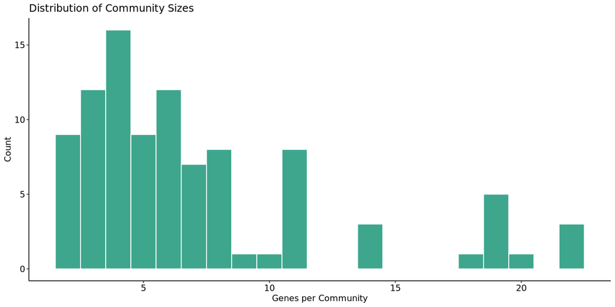

## Cross-genome Communities

| Genome1 | Community1 | Size1 | Genome2 | Community2 | Size2 |
| --- | --- | --- | --- | --- | --- |
| L4_G10300 | Community_10 | 3 | L1_G10000 | Community_11 | 2 |
| L2_G10107 | Community_23 | 14 | L1_G10014 | Community_10 | 14 |
| L2_G10107 | Community_18 | 8 | L4_G10300 | Community_13 | 7 |
| L4_G10300 | Community_28 | 4 | L1_G10000 | Community_17 | 5 |
| L3_G10214 | Community_37 | 4 | L2_G10100 | Community_24 | 5 |
| L4_G10300 | Community_3 | 3 | L3_G10207 | Community_17 | 3 |
| L4_G10314 | Community_36 | 11 | L1_G10000 | Community_32 | 11 |
| L4_G10307 | Community_27 | 6 | L2_G10100 | Community_12 | 6 |
| L4_G10314 | Community_40 | 19 | L3_G10200 | Community_18 | 20 |
| L2_G10114 | Community_26 | 2 | L2_G10100 | Community_17 | 3 |

[output cut: 38 more lines]

## Network Metrics

| Genome1 | Community1 | Size1 | AvgDegree1 | Density1 | AvgClustering1 | Genome2 | Community2 | Size2 | AvgDegree2 | Density2 | AvgClustering2 |
| --- | --- | --- | --- | --- | --- | --- | --- | --- | --- | --- | --- |
| L4_G10300 | Community_10 | 3 | 2 | 1 | 1 | L1_G10000 | Community_11 | 2 | 1 | 1 | 0 |
| L2_G10107 | Community_23 | 14 | 7.631 | 0.587 | 0.757 | L1_G10014 | Community_10 | 14 | 13 | 1 | 1 |
| L2_G10107 | Community_18 | 8 | 7 | 1 | 1 | L4_G10300 | Community_13 | 7 | 6 | 1 | 1 |
| L4_G10300 | Community_28 | 4 | 3 | 1 | 1 | L1_G10000 | Community_17 | 5 | 4 | 1 | 1 |
| L3_G10214 | Community_37 | 4 | 2.319 | 0.773 | 0.772 | L2_G10100 | Community_24 | 5 | 4 | 1 | 1 |
| L4_G10300 | Community_3 | 3 | 1.516 | 0.758 | 0.712 | L3_G10207 | Community_17 | 3 | 2 | 1 | 1 |
| L4_G10314 | Community_36 | 11 | 10 | 1 | 1 | L1_G10000 | Community_32 | 11 | 10 | 1 | 1 |
| L4_G10307 | Community_27 | 6 | 5 | 1 | 1 | L2_G10100 | Community_12 | 6 | 5 | 1 | 1 |
| L4_G10314 | Community_40 | 19 | 18 | 1 | 1 | L3_G10200 | Community_18 | 20 | 19 | 1 | 1 |
| L2_G10114 | Community_26 | 2 | 1 | 1 | 0 | L2_G10100 | Community_17 | 3 | 2 | 1 | 1 |

[output cut: 38 more lines]

# Pangenome Analysis

Gene presence/absence across samples based on pangene analysis.

## Core vs Accessory Genes

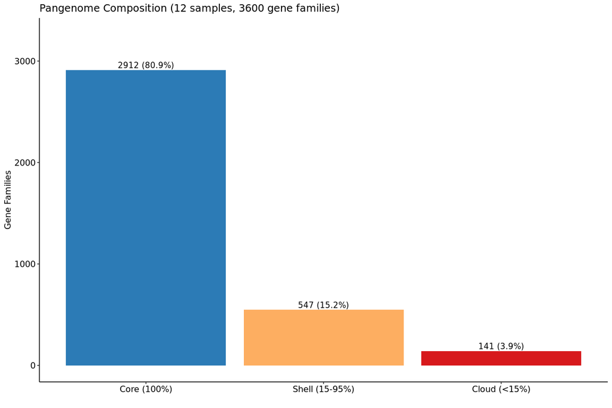

## Gene Frequency Spectrum

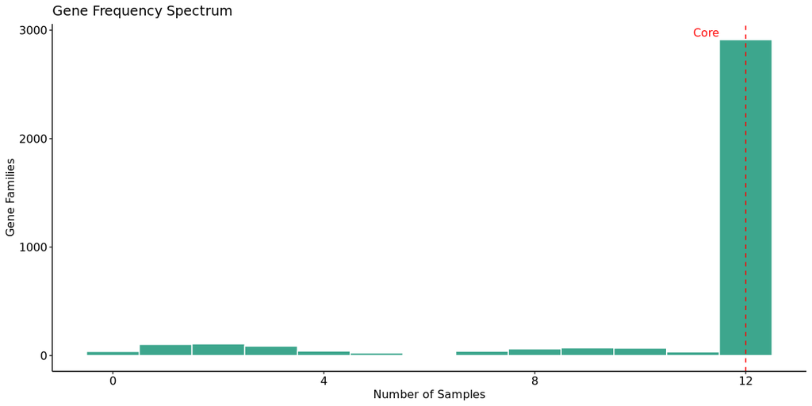

## Presence/Absence Heatmap

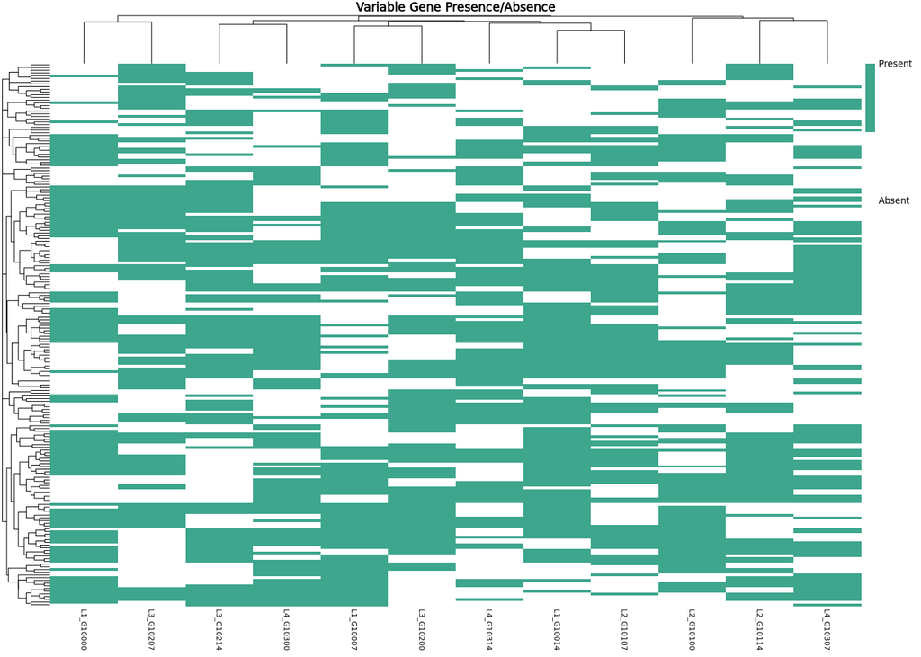

# AMAP CDS Stats

Detailed breakdown of the CDS-correction cases identified by AMAP.

**Classification:**

- **Case 1 keep:** CDS missing from the reference, potentially real novel genes
- **Case 1 remove:** CDS falsely introduced by Bakta, absent from reference
- **Case 2:** Perfect coordinate match with reference
- **Case 3:** Same start/end but containing mismatches
- **Case 4:** Coordinates corrected by AMAP
- **Missing Genes:** Reference genes recovered by AMAP (not annotated by Bakta)

## Boxplot

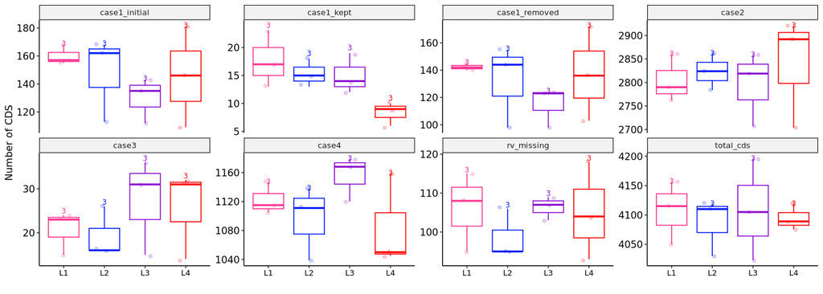

## Violinplot

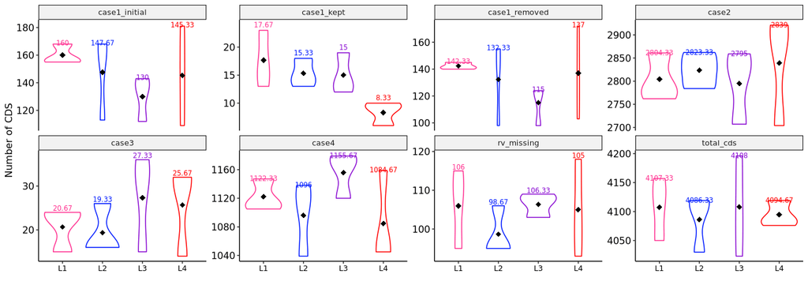

## Histogram Cases

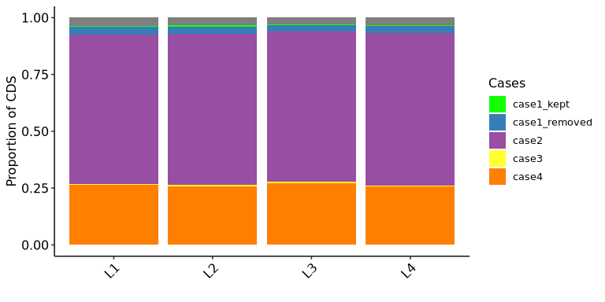

## Heatmap

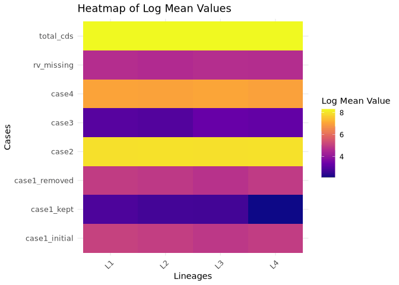

## Per-case Statistics

### Case 1

| Lineages | Count | Mean | SD | Median | IQR | Min | Max |
| --- | --- | --- | --- | --- | --- | --- | --- |
| L1 | 3 | 160 | 7 | 157 | 6.5 | 155 | 168 |
| L2 | 3 | 147.6666666666667 | 30.171730698343 | 162 | 27.5 | 113 | 168 |
| L3 | 3 | 130 | 16.09347693943108 | 135 | 15.5 | 112 | 143 |
| L4 | 3 | 145.3333333333333 | 36.00462933198082 | 146 | 36 | 109 | 181 |

### Case 1 Keep

| Lineages | Count | Mean | SD | Median | IQR | Min | Max |
| --- | --- | --- | --- | --- | --- | --- | --- |
| L1 | 3 | 17.66666666666667 | 5.033222956847166 | 17 | 5 | 13 | 23 |
| L2 | 3 | 15.33333333333333 | 2.516611478423583 | 15 | 2.5 | 13 | 18 |
| L3 | 3 | 15 | 3.605551275463989 | 14 | 3.5 | 12 | 19 |
| L4 | 3 | 8.333333333333334 | 2.081665999466133 | 9 | 2 | 6 | 10 |

### Case 1 Remove

| Lineages | Count | Mean | SD | Median | IQR | Min | Max |
| --- | --- | --- | --- | --- | --- | --- | --- |
| L1 | 3 | 142.3333333333333 | 2.516611478423583 | 142 | 2.5 | 140 | 145 |
| L2 | 3 | 132.3333333333333 | 30.23794525647094 | 144 | 28.5 | 98 | 155 |
| L3 | 3 | 115 | 14.73091986265623 | 123 | 13 | 98 | 124 |
| L4 | 3 | 137 | 34.51086785347479 | 136 | 34.5 | 103 | 172 |

### Case 2

| Lineages | Count | Mean | SD | Median | IQR | Min | Max |
| --- | --- | --- | --- | --- | --- | --- | --- |
| L1 | 3 | 2804.333333333333 | 51.03266927501768 | 2790 | 49.5 | 2762 | 2861 |
| L2 | 3 | 2823.333333333333 | 39.0042732701602 | 2824 | 39 | 2784 | 2862 |
| L3 | 3 | 2795 | 78.79086241436883 | 2819 | 76 | 2707 | 2859 |
| L4 | 3 | 2839 | 117.8091677247573 | 2892 | 108.5 | 2704 | 2921 |

### Case 3

| Lineages | Count | Mean | SD | Median | IQR | Min | Max |
| --- | --- | --- | --- | --- | --- | --- | --- |
| L1 | 3 | 20.66666666666667 | 4.932882862316247 | 23 | 4.5 | 15 | 24 |
| L2 | 3 | 19.33333333333333 | 5.773502691896258 | 16 | 5 | 16 | 26 |
| L3 | 3 | 27.33333333333333 | 10.96965511460289 | 31 | 10.5 | 15 | 36 |
| L4 | 3 | 25.66666666666667 | 10.11599393699568 | 31 | 9 | 14 | 32 |

### Case 4

| Lineages | Count | Mean | SD | Median | IQR | Min | Max |
| --- | --- | --- | --- | --- | --- | --- | --- |
| L1 | 3 | 1122.333333333333 | 21.93931022920578 | 1115 | 21 | 1105 | 1147 |
| L2 | 3 | 1096 | 51.17616632769595 | 1111 | 49.5 | 1039 | 1138 |
| L3 | 3 | 1155.666666666667 | 31.37408697210699 | 1168 | 29.5 | 1120 | 1179 |
| L4 | 3 | 1084.666666666667 | 64.42308075009556 | 1050 | 57 | 1045 | 1159 |

### Total CDS

| Lineages | Count | Mean | SD | Median | IQR | Min | Max |
| --- | --- | --- | --- | --- | --- | --- | --- |
| L1 | 3 | 4107.333333333333 | 53.91041952473876 | 4115 | 53.5 | 4050 | 4157 |
| L2 | 3 | 4086.333333333333 | 48.99319680663157 | 4110 | 44.5 | 4030 | 4119 |
| L3 | 3 | 4108 | 86.53900854527974 | 4105 | 86.5 | 4023 | 4196 |
| L4 | 3 | 4094.666666666667 | 22.05296654269745 | 4089 | 21.5 | 4076 | 4119 |

### Missing Rvs

| Lineages | Count | Mean | SD | Median | IQR | Min | Max |
| --- | --- | --- | --- | --- | --- | --- | --- |
| L1 | 3 | 106 | 10.14889156509222 | 108 | 10 | 95 | 115 |
| L2 | 3 | 98.66666666666667 | 6.350852961085883 | 95 | 5.5 | 95 | 106 |
| L3 | 3 | 106.3333333333333 | 3.055050463303894 | 107 | 3 | 103 | 109 |
| L4 | 3 | 105 | 12.52996408614167 | 104 | 12.5 | 93 | 118 |

# Master Table Explorer

Interactive explorer for the full annotation master table with all functional annotations.

| strand | start | end | rvs | pseudogene | COG_category | Description | Preferred_name | KEGG_Pathway | Functional_Category |
| --- | --- | --- | --- | --- | --- | --- | --- | --- | --- |
| + | 2569521 | 2572356 | Rv0777 | no | D | putative enzyme | - | ko00260 | regulatory proteins |
| + | 2766682 | 2768824 | Rv1962 | no | D | putative enzyme | - | ko00640 | virulence, detoxification, adaptation |
| + | 3531733 | 3532387 | Rv3058 | no | C | putative enzyme | - | ko03010 | lipid metabolism |
| + | 1018504 | 1019659 | Rv3413 | no | I | hypothetical protein | - | ko00620 | conserved hypotheticals |
| + | 74406 | 75837 | Rv3797 | no | N | putative enzyme | - | ko00330 | lipid metabolism |
| - | 2721657 | 2724315 | Rv2948 | no | I | putative enzyme | - | - | lipid metabolism |
| + | 1217000 | 1219676 | Rv0145 | no | H | hypothetical protein | - | ko00010 | conserved hypotheticals |
| - | 2625361 | 2625769 | Rv3344 | no | G | putative enzyme | - | ko03010 | insertion seqs and phages |
| + | 4181490 | 4182291 | Rv2257 | no | G | putative enzyme | - | - | intermediary metabolism and respiration |
| + | 2793508 | 2795689 | Rv1685 | no | P | putative enzyme | - | ko00230 | intermediary metabolism and respiration |

[output cut: 2870 more lines]

*Report generated by AMAP v1.0.1 on 2026-10-24 10:41.*